# homework6

##### 1.Proof:

Let $t_0 \in M_k$ satisfy that $\alpha _k = min_{t_0 \in M_k} g_k(t_0) = \frac{C(t_0)-C(T(t_0))}{\left\vert T_{t_0} \right\vert - 1}$ and $t_1 \in M_{k+1}$ satisfy that $\alpha_{k+1} = min_{t_1 \in M_{k+1}}g_k(t_1) = \frac{C(t_1)-C(T(t_1))}{\left\vert T_{t_1} \right\vert -1}$  
If $t_1$ is not the ancestor node of $t_0$, it is obvious that $\alpha_{k+1} > \alpha_k$  
If $t_1$ is the ancestor node of $t_0$, let $t_{10}$ is the mark of node $t_1$ before pruning.  
We have $\begin{cases} \frac{C(t_{10})-C(T_{t_{10}})}{\left\vert T_{t_{10}} \right\vert - 1} > \alpha_k \\ C(t_{10}) = C(t_1)\\ \left\vert T_{t_1} \right\vert = \left\vert T_{t_{10}} \right\vert - \left\vert T_{t_0} \right\vert +1 \\ C(T_{t_1}) = C(T_{t_{10}}) - C(T_{t_0}) + C(t_0) \end{cases}$.  
Thus, $\alpha_{k+1} = \frac{C(t_1)-C(T(t_1))}{\left\vert T_{t_1} \right\vert -1} =\frac{C(t_{10})-C(T_{t_{10}})+C(T_{t_0})-C(t_0)}{\left\vert T_{t_{10}} \right\vert - \left\vert T_{t_0} \right\vert}>\frac{\alpha_k(\left\vert T_{t_{10}} \right\vert - 1)-\alpha_k(\left\vert T_{t_{0}} \right\vert - 1)}{\left\vert T_{t_{10}} \right\vert - \left\vert T_{t_0} \right\vert}=\alpha_k$.  
So, $\alpha_{k+1} > \alpha_k$.

##### 2.Proof:

Since $0 \le p_i \le 1,i=1,2,\cdots,n$, it is obvious that $H(X) \ge 0$. And when $p_j = 1, p_i = 0 \thickspace for \thickspace all \thickspace 1 \le i \le n\thickspace and \thickspace i \ne j$, we have $H(X)=0$.  
By Jensen Inequality, we have $\sum_{i=1}^n p_ilog{\frac{1}{p_i}} \le log(\sum_{i=1}^np_i \frac{1}{p_i})=logn$. When $p_i = \frac{1}{n}, \thickspace i=1, 2, \cdots, n$, we have $H(X)=logn$.  
So, $0 \le H(X) \le logn$.

```python
'''(3.1)'''
import numpy as np
import pandas as pd
import matplotlib.pyplot as plt

simudata = pd.read_csv("simudata.csv")
```

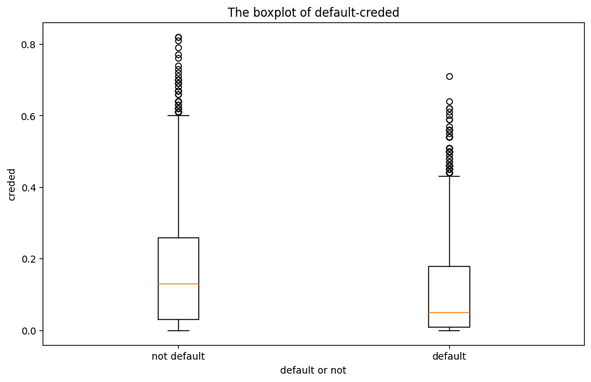

```python
'''(3.2)'''
notblack = simudata[simudata['black'] == 0]
black = simudata[simudata['black'] == 1]
data_creded = [notblack['creded'], black["creded"]]

plt.figure(figsize=(10, 6))
plt.title("The boxplot of default-creded")
plt.boxplot(data_creded, labels=["not default", "default"])
plt.xlabel("default or not")
plt.ylabel("creded")
plt.show()
```

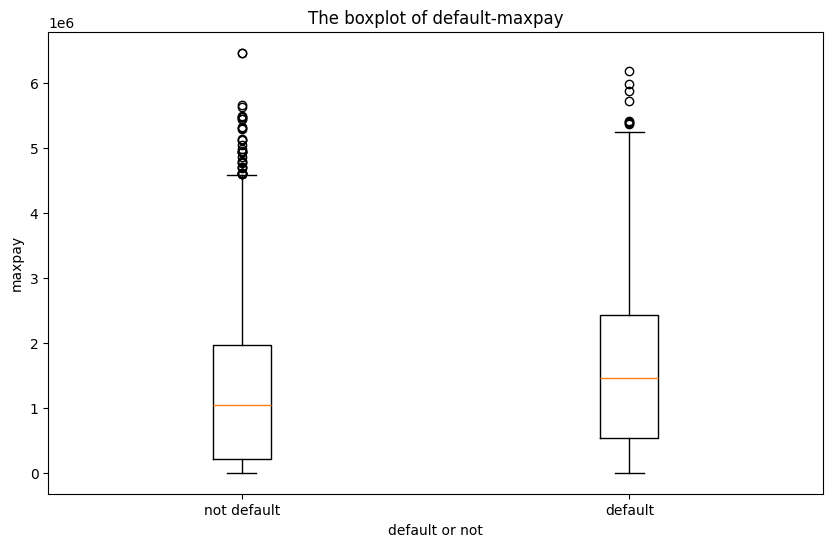

```python
data_maxpay = [notblack["maxpay"], black["maxpay"]]
plt.figure(figsize=(10, 6))
plt.boxplot(data_maxpay, labels=["not default", "default"])
plt.xlabel("default or not")
plt.ylabel('maxpay')
plt.title("The boxplot of default-maxpay")
plt.show()
```

```
The value of AUC is 0.60
```

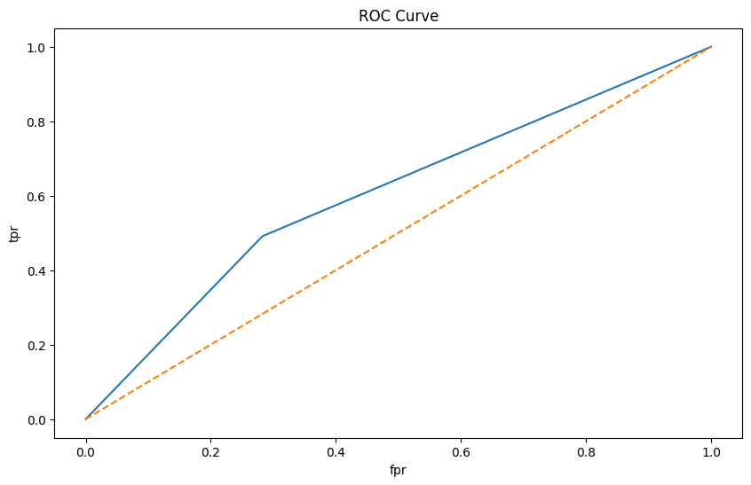

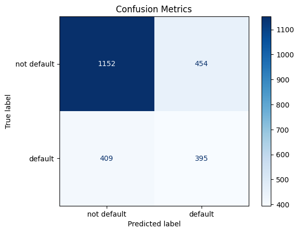

```
TP:395,FP:454,TN:1152,FN:409,Accuracy:0.64,Precision:0.47,Recall:0.49
```

```python
'''(3.3)'''
from sklearn.model_selection import train_test_split
from sklearn.tree import DecisionTreeClassifier, plot_tree
from sklearn.metrics import roc_curve, auc, confusion_matrix, ConfusionMatrixDisplay

X = simudata.drop("black", axis=1)
y = simudata["black"]

X_train, X_test, y_train, y_test = train_test_split(X, y, train_size=0.7, test_size=0.3, random_state=2024, stratify=y)
model = DecisionTreeClassifier(random_state=2024)
model.fit(X_train, y_train)

y_pred_prob = model.predict_proba(X_test)[:, 1]
y_pred = model.predict(X_test)

fpr, tpr, _ = roc_curve(y_test, y_pred_prob)
roc_auc = auc(fpr, tpr)
print(f"The value of AUC is {roc_auc:.2f}")

plt.figure(figsize=(10, 6))
plt.plot(fpr, tpr, label=f'ROC(AUC={roc_auc:.2f})')
plt.plot([0, 1], [0, 1], linestyle="--")
plt.xlabel("fpr")
plt.ylabel("tpr")
plt.title("ROC Curve")
plt.show()

cm = confusion_matrix(y_test, y_pred)
disp = ConfusionMatrixDisplay(confusion_matrix=cm, display_labels=["not default", "default"])
disp.plot(cmap=plt.cm.Blues)
plt.title("Confusion Metrics")
plt.show()

tn, fp, fn, tp = cm.ravel()
print(f"TP:{tp},FP:{fp},TN:{tn},FN:{fn},Accuracy:{(tp+tn)/(tp+tn+fp+fn):.2f},Precision:{tp/(tp+fp):.2f},Recall:{tp/(tp+fn):.2f}")
```

AUC的值为0.6，混淆矩阵的参数如上，真正例个数为395，假正例个数为454，真负例个数为1152，假负例个数为409， 准确率为0.64，精确率为0.47，召回率为0.49.

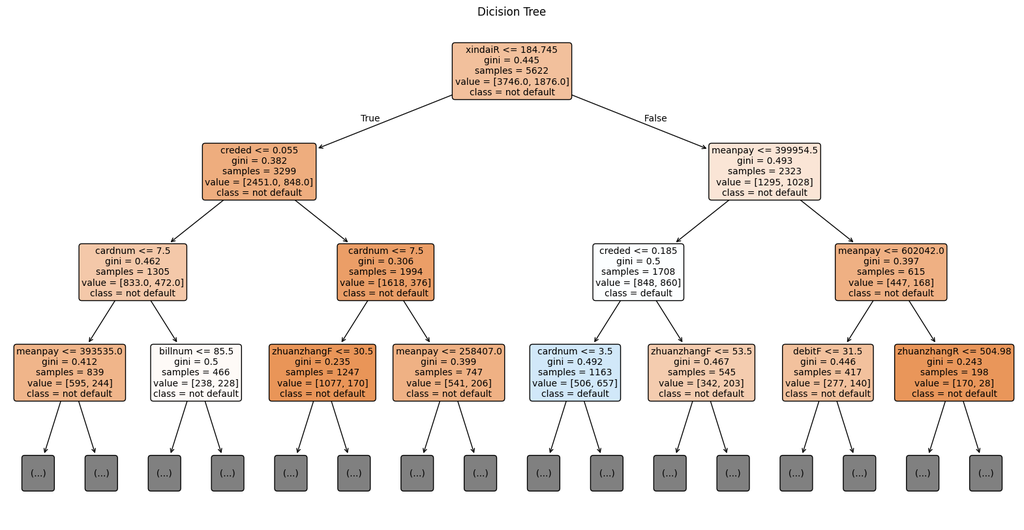

```python
plt.figure(figsize=(20, 10))
plot_tree(
    model,
    feature_names=X.columns,
    class_names=['not default', 'default'],
    filled=True,
    rounded=True,
    fontsize=10,
    max_depth=3
)
plt.title('Dicision Tree')
plt.show()
```

决策树根节点为xindaiR.图中未展现整个决策树，其中方框为橙色的代表主导种类为非违约组，颜色越深非违约组占比越多，蓝色代表主导种类为违约组，颜色越深代表违约组占比越多，白色代表差别比较小。